# R-project for Ecological modelling

Jedi this did (с)Yoda

A long time ago in a galaxy far, far away….

[figure not shown]

# Обработка данных исходной таблицы

Для создания модели линейной регрессии дневных потоков паров воды были взяты данные за осенний период 2013 года по данным измерений методом турбулентной пульсации. Табличным данным, надо которыми производилась работа, было присвоено имя tbl для удобства работы

```
tbl = read_csv("eddypro.csv")
```

В ходе запуска файла “tbl” выяснилось, что переменная представляет собой огромный массив данных, который необходимо преобразовать для дальнейшей работы. Так как данные были получены компьютером, то некоторые отсутствующие значения были представлены в виде “-9999”, которые заменили на “NA”. Помимо недостающих значений присутствовали текстовые данные, которые мы удалили, так как они помешали бы проведению обработки данных и корреляции.

```
tbl = read_csv("eddypro.csv", skip = 1, na=c("","NA","-9999","-9999.0"),comment =c("["))
tbl = tbl [-1,]
tbl
names(tbl)
```

удаляем ненужные столбцы

```
tbl = select(tbl, -(roll))
tbl = tbl [,c(-1,-3,-6,-7,-9,-12,-15,-18,-21,-30,-35,-70,-88:-99)]
names(tbl )
```

выбираем заданные в задании время года и время суток

```
tbl <- tbl [tbl $DOY>244 & tbl $DOY<315 & tbl $daytime == FALSE, c(1:ncol(tbl))]
```

# Корреляционный анализ

```
tbl = tbl %>% mutate_if(is.character, factor)
names(tbl) = str_replace_all(names(tbl), "[!]","_emph_")
names(tbl) = names(tbl) %>%
str_replace_all("[!]","_emph_") %>%
str_replace_all("[?]","_quest_") %>%
str_replace_all("[*]","_star_") %>%
str_replace_all("[+]","_plus_") %>%
str_replace_all("[-]","_minus_") %>%
str_replace_all("[@]","_at_") %>%
str_replace_all("[$]","_dollar_") %>%
str_replace_all("[#]","_hash_") %>%
str_replace_all("[/]","_div_") %>%
str_replace_all("[%]","_perc_") %>%
str_replace_all("[&]","_amp_") %>%
str_replace_all("[\\^]","_power_") %>%
str_replace_all("[()]","_")
glimpse(tbl)
```

проводим корреляцию только числовых значений sapply(tbl,is.numeric)

```
eddy_numeric = tbl [,sapply(eddy,is.numeric) ]
eddy_nonnumeric = tbl [,!sapply(eddy,is.numeric) ]
cor_td = cor(tbl _numeric)
cor_td
cor_td = cor(drop_na(tbl_numeric)) %>% as.data.frame %>% select(h2o_flux)
vars = row.names(cor_td)[cor_td$h2o_flux^2 > .1] %>% na.exclude
```

# Получение формулы и создание линейной модели

После проведения корреляции получилась формула зависимости паров воды от переменных. Полученные данные корреляции собираем в модель и проводим анализ адекватности модели, исключая при этом переменные, которые не оказывают при взаимодействии влияния на потоки паров воды Наблюдаем P-значения первой модели, отбрасываем те переменные, для которых он принимает незначимые значения.

```
formula = as.formula(paste("h2o_flux~", paste(vars,collapse = "+"), sep=""))
```

Делаем тест обучающей модели

```
row_numbers = 1:length(tbl $date)
teach = sample(row_numbers, floor(length(tbl $date)*.7))
test = row_numbers[-teach]
teaching_ tbl _unq = tbl [teach,]
testing_ tbl _unq = tbl [test,]
mod = lm(formula, data= tbl)
mod
coef(mod)
resid(mod)
confint(mod)
summary(mod)
anova(mod)
```

далее создаём и анализируем модели множественной регрессии с взаимодействием

```
model1 = lm(h2o_flux ~ (rand_err_Tau + H + LE + rand_err_LE + h2o_flux + rand_err_h2o_flux + co2_molar_density + co2_mixing_ratio + RH + VPD + max_speed + u_star_ + TKE + T_star_ + un_H + un_LE + un_h2o_flux + u_var +
v_var + w_div_ts_cov + w_div_h2o_cov + co2_signal_strength_7200)^2, data = tbl)
model1
coef(model1)
resid(model1)
confint(model1)
summary(model1)
```

```
anova(model1)
```

Проделываем циклично до тех пор, пока не будет получена идеальная модель, в которой все переменные и взаимодействия будут значимыми, при этом коэффициент детерминации будет оставаться неизменным или меняться незначительно. Готовая полученная модель:

[output not shown]

```
coef(model4)
resid(model4)
confint(model4)
summary(model4)
anova(model4)

           Response: h2o_flux
                                      Df Sum Sq Mean Sq    F value    Pr(>F)
DOY                                    1  16.20   16.20 5.6516e+10 < 2.2e-16 ***
Tau                                    1 137.16  137.16 4.7847e+11 < 2.2e-16 ***
rand_err_Tau                           1 217.63  217.63 7.5916e+11 < 2.2e-16 ***
H                                      1 417.70  417.70 1.4571e+12 < 2.2e-16 ***
LE                                     1 370.24  370.24 1.2915e+12 < 2.2e-16 ***
rand_err_LE                            1   0.00    0.00 1.5542e+06 < 2.2e-16 ***
co2_flux                               1   0.00    0.00 2.2109e+04 < 2.2e-16 ***
rand_err_co2_flux                      1   0.00    0.00 4.3151e+05 < 2.2e-16 ***
rand_err_h2o_flux                      1   0.01    0.01 3.9286e+07 < 2.2e-16 ***
h2o_time_lag                           1   0.00    0.00 3.7090e+04 < 2.2e-16 ***
VPD                                    1   0.00    0.00 3.4891e+02 < 2.2e-16 ***
u_star_                                1   0.00    0.00 5.3087e+04 < 2.2e-16 ***
TKE                                    1   0.00    0.00 1.9961e+02 < 2.2e-16 ***
T_star_                                1   0.00    0.00 1.3191e+04 < 2.2e-16 ***
un_Tau                                 1   0.00    0.00 3.8615e+02 < 2.2e-16 ***
un_H                                   1   0.00    0.00 2.4310e+05 < 2.2e-16 ***
un_LE                                  1   0.00    0.00 6.2493e+04 < 2.2e-16 ***
un_h2o_flux                            1   0.00    0.00 2.1275e+06 < 2.2e-16 ***
mean_value                             1   0.00    0.00 2.0583e+02 < 2.2e-16 ***
w_var                                  1   0.00    0.00 3.7709e+02 < 2.2e-16 ***
w_div_h2o_cov                          1   0.00    0.00 8.7219e+01 < 2.2e-16 ***
h2o_signal_strength_7200               1   0.00    0.00 2.6290e+02 < 2.2e-16 ***
DOY:Tau                                1   0.00    0.00 6.6155e+01 1.013e-15 ***
DOY:rand_err_Tau                       1   0.00    0.00 1.6294e+03 < 2.2e-16 ***
DOY:H                                  1   0.00    0.00 2.3560e+01 1.367e-06 ***
DOY:LE                                 1   0.00    0.00 1.2003e+03 < 2.2e-16 ***
DOY:rand_err_LE                        1   0.00    0.00 9.5960e+00 0.0019944 **
DOY:co2_flux                           1   0.00    0.00 1.1938e+01 0.0005687 ***
DOY:rand_err_co2_flux                  1   0.00    0.00 2.9305e+01 7.435e-08 ***
DOY:rand_err_h2o_flux                  1   0.00    0.00 2.1242e+02 < 2.2e-16 ***
DOY:h2o_time_lag                       1   0.00    0.00 9.1872e+00 0.0024883 **
DOY:RH                                 1   0.00    0.00 8.2227e+01 < 2.2e-16 ***
```

[output cut: 49 more lines]

```
co2_flux:T_star_                       1   0.00    0.00 1.0070e+01 0.0015445 **
rand_err_h2o_flux:VPD                  1   0.00    0.00 1.4975e+01 0.0001147 ***
rand_err_h2o_flux:un_h2o_flux          1   0.00    0.00 1.2433e+03 < 2.2e-16 ***
rand_err_h2o_flux:w_div_h2o_cov        1   0.00    0.00 6.1709e+01 8.656e-15 ***
RH:VPD                                 1   0.00    0.00 4.1737e+01 1.503e-10 ***
RH:T_star_                             1   0.00    0.00 1.4598e+01 0.0001397 ***
VPD:h2o_signal_strength_7200           1   0.00    0.00 7.2751e+00 0.0070876 **
u_star_:w_var                          1   0.00    0.00 1.8028e+01 2.341e-05 ***
u_star_:w_div_h2o_cov                  1   0.00    0.00 9.5837e+00 0.0020077 **
T_star_:un_h2o_flux                    1   0.00    0.00 1.0444e+01 0.0012630 **
T_star_:h2o_signal_strength_7200       1   0.00    0.00 1.2911e+01 0.0003396 ***
un_Tau:un_LE                           1   0.00    0.00 2.5087e+01 6.282e-07 ***
un_H:w_div_h2o_cov                     1   0.00    0.00 7.0777e+00 0.0079070 **
un_LE:h2o_signal_strength_7200         1   0.00    0.00 3.5951e+01 2.658e-09 ***
mean_value:h2o_signal_strength_7200    1   0.00    0.00 3.4850e+01 4.604e-09 ***
```

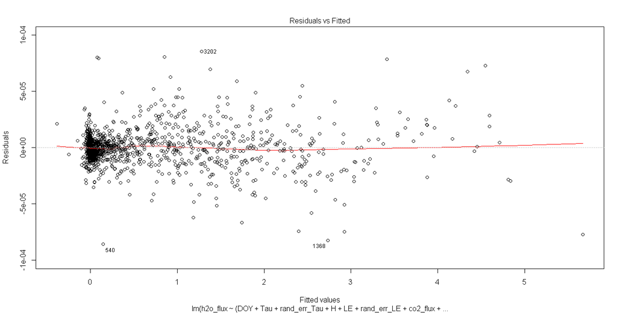

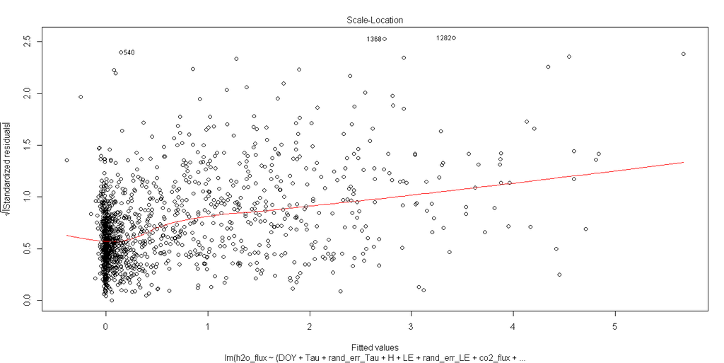

[figure not shown]

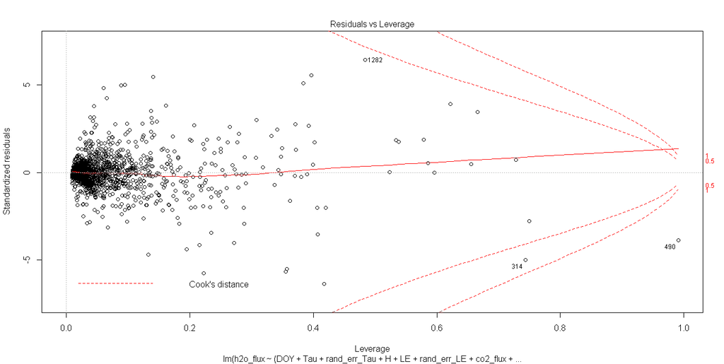

## **СПАСИБО ЗА ВНИМАНИЕ**

[figure not shown]

may the Force be with you